# data-inventory

```r
build_sp_race2("OPERATIONS", "diff_MULTI", c(-100,-10,-5,-2.5,0,2.5,5,10,20,100), "Difference in % Operations\nMulti-race Folx (2002-2017)")
```

```
## Variable(s) "diff_MULTI" contains positive and negative values, so midpoint is set to 0. Set midpoint = NA to show the full spectrum of the color palette.
```

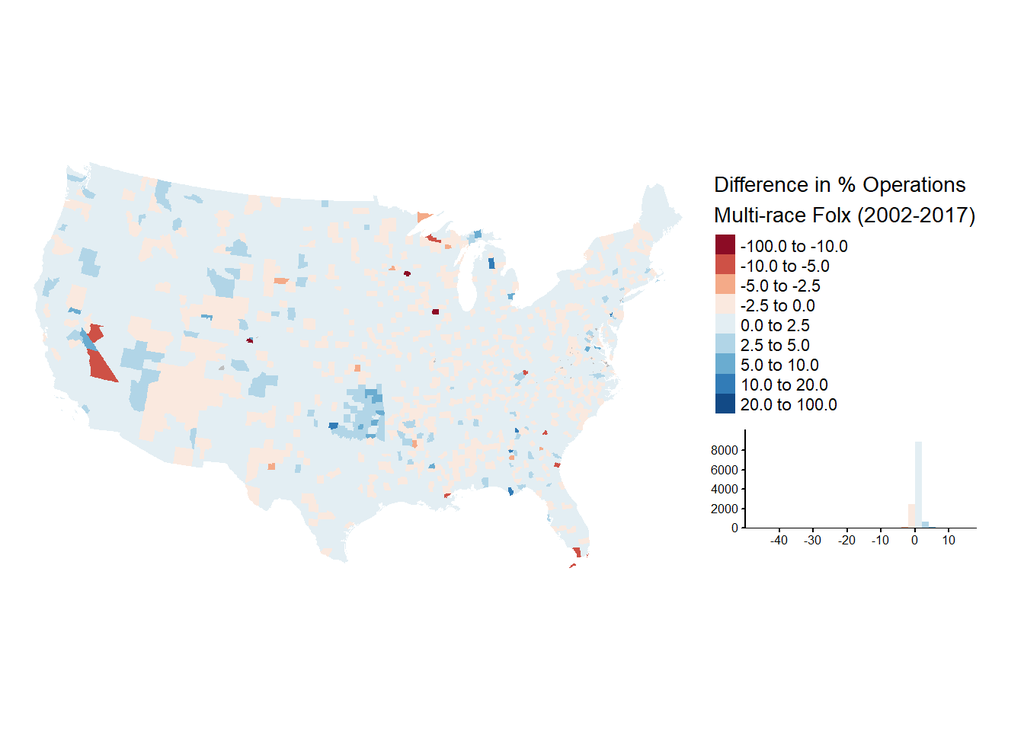

```r
build_sp_race2("OPERATIONS", "diff_HISPANIC", c(-100,-10,-5,-2.5,0,2.5,5,10,20,100), "Difference in % Operations\nHispanic Folx (2002-2017)")
```

```
## Variable(s) "diff_HISPANIC" contains positive and negative values, so midpoint is set to 0. Set midpoint = NA to show the full spectrum of the color palette.
```

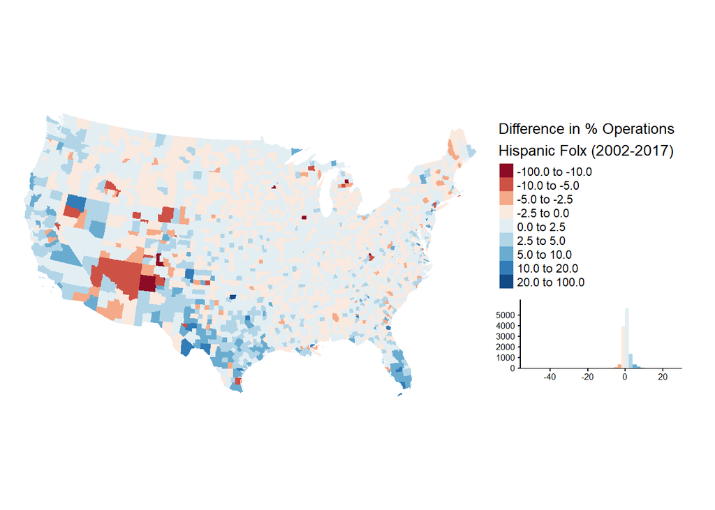

```
## Variable(s) "diff_TOTAL" contains positive and negative values, so midpoint is set to 0. Set midpoint = NA to show the full spectrum of the color palette.
```

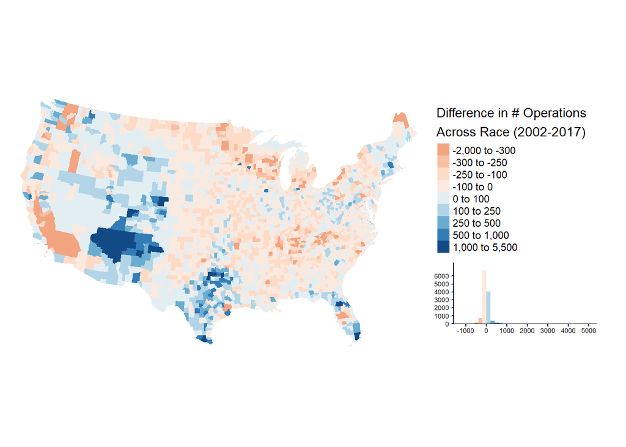

```r
build_sp_race2("OPERATIONS", "diff_TOTAL", c(-2000,-300,-250,-100,0,100,250,500,1000,5500), "Difference in # Operations\nAcross Race (2002-2017)") # for some reason this last map isn't visualizing correctly
```

Interesting stuff here, too. As Horst & Marion point out, and as we know, the COA is inconsistent--in this case, for disclosure reasons (I'm guessing). So in some counties, we see that there are 2 Hispanic operators, but do not see their acreage recorded and visa versa. So we would have to lead with this caveat. There is very little missing data for 'OPERATIONS' or 'OPERATORS', but much more missing for 'ACRES OPERATED'. The racial composition of counties is changing variably across space and time, with some places like the southwest becoming more Native operated (so cool!). Lots of other trends to be aware of here, too!

# Age, Experience, Tenure

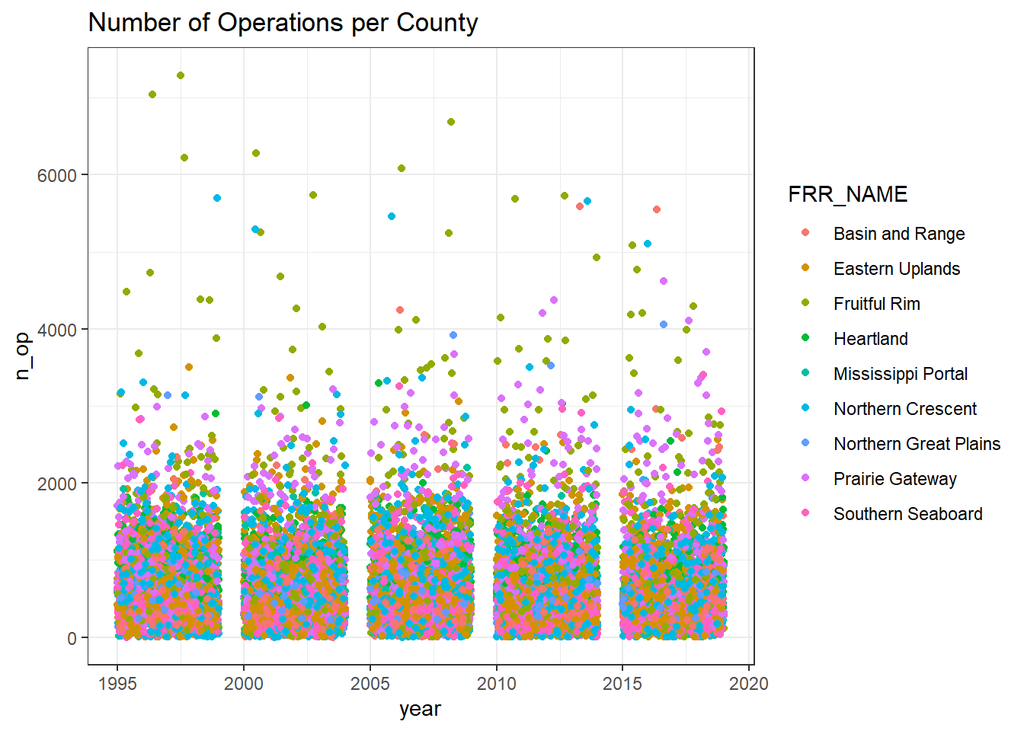

```r
FRR <- readRDS("./data/FRR.RDS")
BSDS <- readRDS("./data/BSDS_att_raw.RDS")
atts <- BSDS %>% select(GEOID,county, year, age, exp, full_owner, part_owner, tenant,n_op,tot_acres,acres_per_op) %>%
  mutate(owner = full_owner + part_owner, # number of owners (including partial owners)
         p_own = owner / (owner + tenant)*100, # percent acres operated by owners (including partial owners)
         ave_acres_op = tot_acres/n_op)  %>%
    mutate_at(13:14, round, 1)

# Add FRR for faceting, viz, etc.
FRR <- FRR %>%
  select(GEOID, FRR, FRR_NAME)

atts <- merge(atts, FRR, by = "GEOID")

# Start viz
# Number of operations
ggplot(atts) +
  geom_jitter(aes(x = year, y = n_op, color = FRR_NAME)) +
  #scale_y_continuous(limits = c(5, 20)) +
  theme_bw() +
  labs(title = "Number of Operations per County")
```

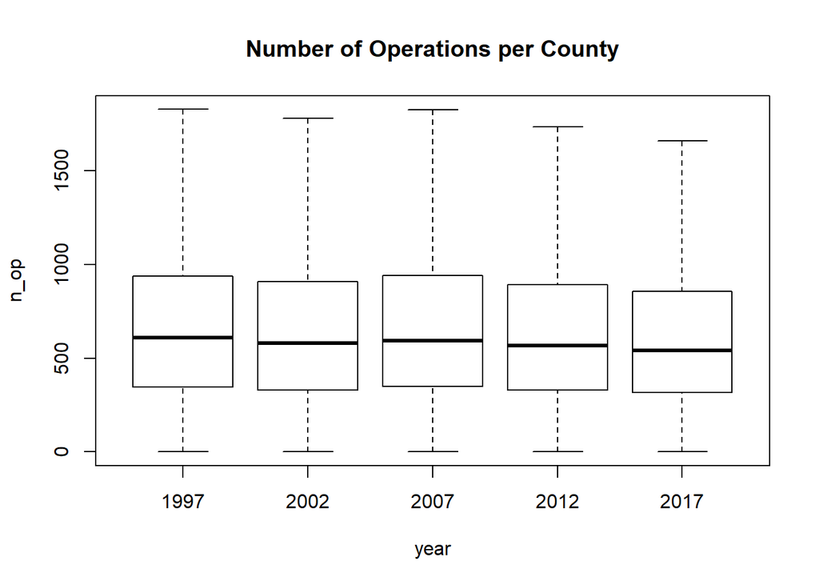

```r
boxplot(n_op ~ year, data = atts, main = "Number of Operations per County", outline = FALSE)
```

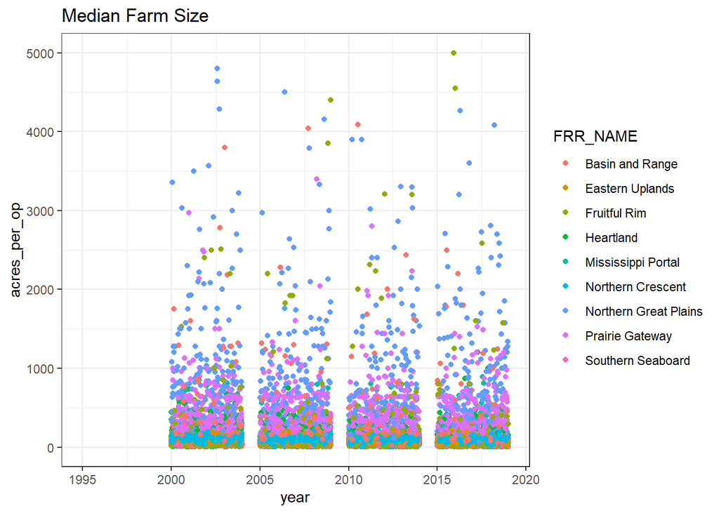

```r
# Median farm size
ggplot(atts) +
  geom_jitter(aes(x = year, y = acres_per_op, color = FRR_NAME)) +
  scale_y_continuous(limits = c(0, 5000)) +
  theme_bw() +
  labs(title = "Median Farm Size")
```

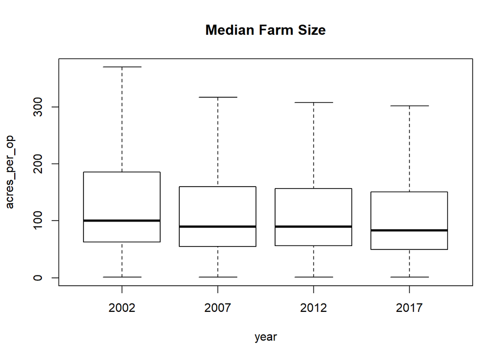

```r
boxplot(acres_per_op ~ year, data = atts, main = "Median Farm Size", outline = FALSE)
```

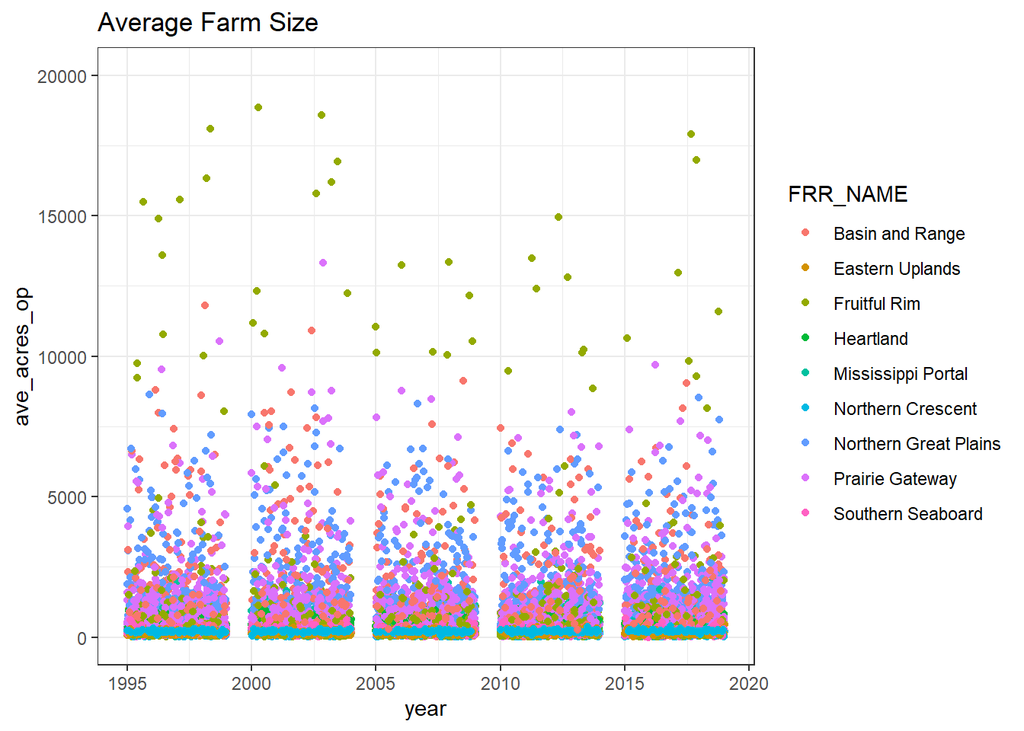

```r
# Average farm size
ggplot(atts) +
  geom_jitter(aes(x = year, y = ave_acres_op, color = FRR_NAME)) +
  scale_y_continuous(limits = c(0, 20000)) +
  theme_bw() +
  labs(title = "Average Farm Size")
```

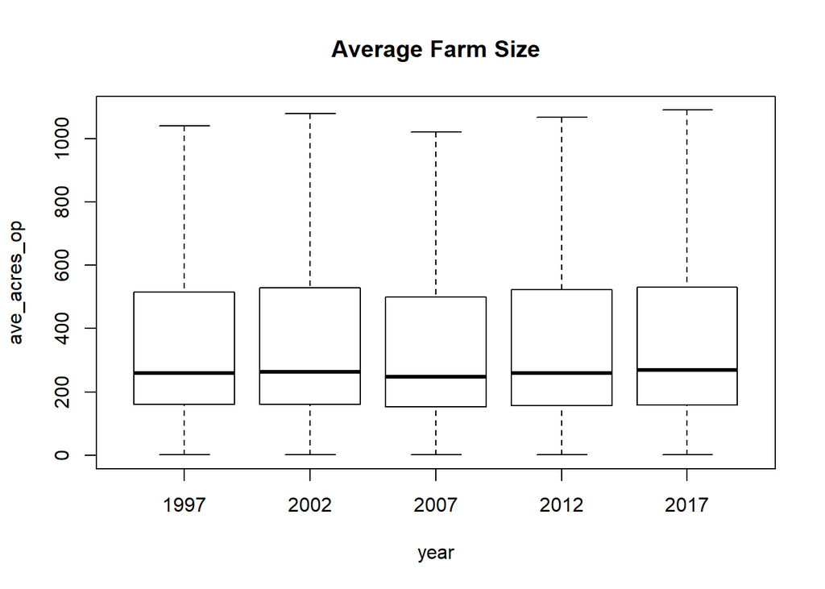

```r
boxplot(ave_acres_op ~ year, data = atts, main = "Average Farm Size", outline = FALSE)
```

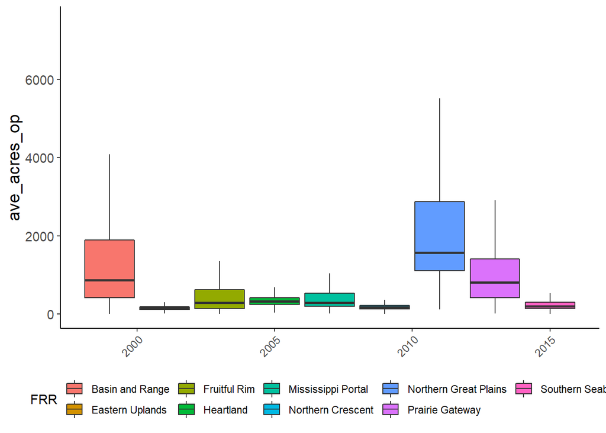

```r
ggplot(atts, aes(x = year, y = ave_acres_op, fill = FRR_NAME)) +
  geom_boxplot(outlier.shape = NA) +
  labs(fill = "FRR") +
  theme_classic() +
  theme(axis.title=element_text(size=14),
        axis.text=element_text(size=11)) +
  theme(axis.title.x=element_blank(),
        axis.text.x=element_text(size=9, angle=45, hjust = 1)) +
  theme(strip.background = element_blank()) +
  theme(legend.position = "bottom") +
  #scale_fill_manual(name = "FRR_NAME", values=colors) +
  coord_cartesian(ylim = c(0,7500))
```

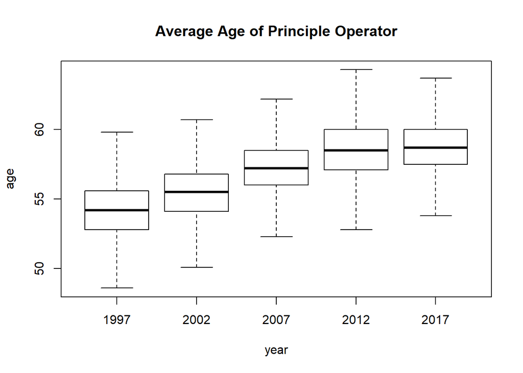

```r
boxplot(age ~ year, data = atts, main = "Average Age of Principle Operator", outline=FALSE)
```

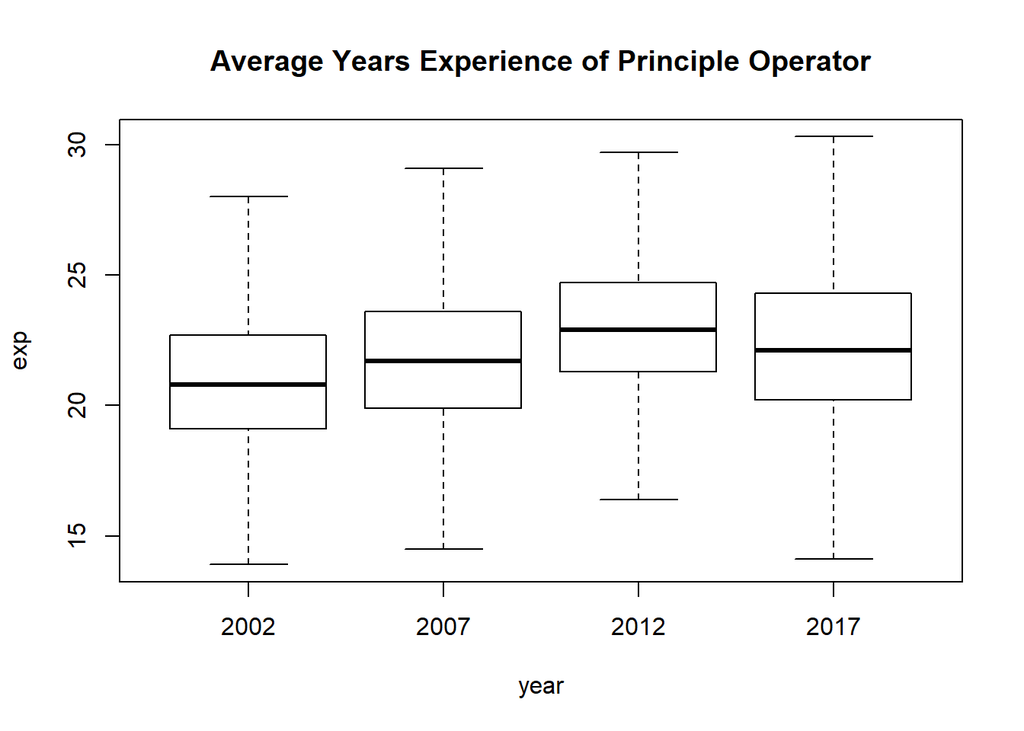

```r
boxplot(exp ~ year, data = atts, main = "Average Years Experience of Principle Operator", outline=FALSE)
```

Potential trash, below

```r
# Build function

build_final <- function(RDS){

file <- readRDS(RDS)

out <- file %>%
  select(COUNTY_NAME, STATE_NAME, YEAR, GEOID, VALUE)

# Where NA, change to 0 to sum where apropriate
out[is.na(out)] <- 0

# sum across GEOID on the Value column (necesary for: labor_expense, prod_n, and corn_harv, etc.; just easier to do within function)
out <- out %>%
  group_by(GEOID, YEAR) %>%
  mutate(V = sum(VALUE)) %>%
  distinct(GEOID, .keep_all=TRUE) %>%
  select(COUNTY_NAME, YEAR, GEOID, V)

# Where 0, change back to NA; there are no reports of 0 in any county for any indicator, SO, wherever a zero appears, the county reported "NA" across all indicator categories.
out$V[out$V == "0"] <- NA

# must change this to the file # in the list created above with each iteration of the function, below
name <- file_path_sans_ext(basename(RDS_file_list[[40]]))

colnames(out) <- c("county", "year", "GEOID", name)

return(out)
}
```